# Smarket Analysis with R Notebook

Classifier - Logistic regression, LDA, QDA, KNN & decision tree

Peter Morris

October 22, 2021

# Smarket - Data set

Library: ISLR2

Exploratory Analysis S&P Stock Market Data Description Daily percentage returns for the S&P 500 stock index between 2001 and 2005.

Usage Smarket Format - A data frame with 1250 observations on the following 9 variables.

Year - The year that the observation was recorded

Lag1 - Percentage return for previous day

Lag2 - Percentage return for 2 days previous

Lag3 - Percentage return for 3 days previous

Lag4 - Percentage return for 4 days previous

Lag5 - Percentage return for 5 days previous

Volume - Volume of shares traded (number of daily shares traded in billions)

Today - Percentage return for today

Direction - A factor with levels Down and Up indicating whether the market had a positive or negative return on a given day

Source - Raw values of the S&P 500 were obtained from Yahoo Finance and then converted to percentages and lagged.

# Bibliography

1. Gareth James, Daniela Witten, Trevor Hastie Robert Tibshirani - An Introduction to Statistical Learning with Applications in R

For further volumes: http://www.springer.com/series/417

2. https://discuss.analyticsvidhya.com/t/how-does-complexity-parameter-cp-work-in-decision-tree/6589

# Exploratory Analysis

Variables

```r
# library(ISLR2)
# library(MASS)
# library(ggplot2)
# library(lattice)
# library(FNN)

# package list
libs.install <- c("ISLR2", "MASS", "ggplot2", "lattice", "FNN", "mvShapiroTest", "randtests", "pROC", "rpart", "rpart.plot")
# installing packages
for (lib in libs.install) {
  if (!require(lib, character.only = TRUE)) {
    install.packages(lib, dependencies = TRUE)
    library(lib, character.only = TRUE)
  }
}

attach(Smarket)
```

```r
names(Smarket)
```

```
## [1] "Year"      "Lag1"      "Lag2"      "Lag3"      "Lag4"      "Lag5"
## [7] "Volume"    "Today"     "Direction"
```

Dimension - Lines vs. Columns

```r
dim(Smarket)
```

```
## [1] 1250    9
```

Data set summary

```r
summary(Smarket)
```

```
##       Year           Lag1                Lag2                Lag3
##  Min.   :2001   Min.   :-4.922000   Min.   :-4.922000   Min.   :-4.922000
##  1st Qu.:2002   1st Qu.:-0.639500   1st Qu.:-0.639500   1st Qu.:-0.640000
##  Median :2003   Median : 0.039000   Median : 0.039000   Median : 0.038500
##  Mean   :2003   Mean   : 0.003834   Mean   : 0.003919   Mean   : 0.001716
##  3rd Qu.:2004   3rd Qu.: 0.596750   3rd Qu.: 0.596750   3rd Qu.: 0.596750
##  Max.   :2005   Max.   : 5.733000   Max.   : 5.733000   Max.   : 5.733000
##       Lag4                Lag5              Volume           Today
##  Min.   :-4.922000   Min.   :-4.92200   Min.   :0.3561   Min.   :-4.922000
##  1st Qu.:-0.640000   1st Qu.:-0.64000   1st Qu.:1.2574   1st Qu.:-0.639500
##  Median : 0.038500   Median : 0.03850   Median :1.4229   Median : 0.038500
##  Mean   : 0.001636   Mean   : 0.00561   Mean   :1.4783   Mean   : 0.003138
##  3rd Qu.: 0.596750   3rd Qu.: 0.59700   3rd Qu.:1.6417   3rd Qu.: 0.596750
##  Max.   : 5.733000   Max.   : 5.73300   Max.   :3.1525   Max.   : 5.733000
##  Direction
##  Down:602
##  Up  :648
##
##
##
##
```

```r
head(Smarket)
```

|  | Year | Lag1 | Lag2 | Lag3 | Lag4 | Lag5 | Volume | Today | Direction |
| --- | --- | --- | --- | --- | --- | --- | --- | --- | --- |
| 1 | 2001 | 0.381 | -0.192 | -2.624 | -1.055 | 5.010 | 1.1913 | 0.959 | Up |
| 2 | 2001 | 0.959 | 0.381 | -0.192 | -2.624 | -1.055 | 1.2965 | 1.032 | Up |
| 3 | 2001 | 1.032 | 0.959 | 0.381 | -0.192 | -2.624 | 1.4112 | -0.623 | Down |
| 4 | 2001 | -0.623 | 1.032 | 0.959 | 0.381 | -0.192 | 1.2760 | 0.614 | Up |
| 5 | 2001 | 0.614 | -0.623 | 1.032 | 0.959 | 0.381 | 1.2057 | 0.213 | Up |
| 6 | 2001 | 0.213 | 0.614 | -0.623 | 1.032 | 0.959 | 1.3491 | 1.392 | Up |

```r
tail(Smarket)
```

|  | Year | Lag1 | Lag2 | Lag3 | Lag4 | Lag5 | Volume | Today | Direction |
| --- | --- | --- | --- | --- | --- | --- | --- | --- | --- |
| 1245 | 2005 | 0.252 | -0.024 | -0.584 | -0.285 | -0.141 | 2.06517 | 0.422 | Up |
| 1246 | 2005 | 0.422 | 0.252 | -0.024 | -0.584 | -0.285 | 1.88850 | 0.043 | Up |
| 1247 | 2005 | 0.043 | 0.422 | 0.252 | -0.024 | -0.584 | 1.28581 | -0.955 | Down |
| 1248 | 2005 | -0.955 | 0.043 | 0.422 | 0.252 | -0.024 | 1.54047 | 0.130 | Up |
| 1249 | 2005 | 0.130 | -0.955 | 0.043 | 0.422 | 0.252 | 1.42236 | -0.298 | Down |
| 1250 | 2005 | -0.298 | 0.130 | -0.955 | 0.043 | 0.422 | 1.38254 | -0.489 | Down |

Data set is ordered by Year

```r
cor(Smarket[,-9])
```

```
##              Year         Lag1         Lag2         Lag3         Lag4
## Year   1.00000000  0.029699649  0.030596422  0.033194581  0.035688718
## Lag1   0.02969965  1.000000000 -0.026294328 -0.010803402 -0.002985911
## Lag2   0.03059642 -0.026294328  1.000000000 -0.025896670 -0.010853533
## Lag3   0.03319458 -0.010803402 -0.025896670  1.000000000 -0.024051036
## Lag4   0.03568872 -0.002985911 -0.010853533 -0.024051036  1.000000000
## Lag5   0.02978799 -0.005674606 -0.003557949 -0.018808338 -0.027083641
## Volume 0.53900647  0.040909908 -0.043383215 -0.041823686 -0.048414246
## Today  0.03009523 -0.026155045 -0.010250033 -0.002447647 -0.006899527
##                Lag5      Volume        Today
## Year    0.029787995  0.53900647  0.030095229
## Lag1   -0.005674606  0.04090991 -0.026155045
## Lag2   -0.003557949 -0.04338321 -0.010250033
## Lag3   -0.018808338 -0.04182369 -0.002447647
## Lag4   -0.027083641 -0.04841425 -0.006899527
## Lag5    1.000000000 -0.02200231 -0.034860083
## Volume -0.022002315  1.00000000  0.014591823
## Today  -0.034860083  0.01459182  1.000000000
```

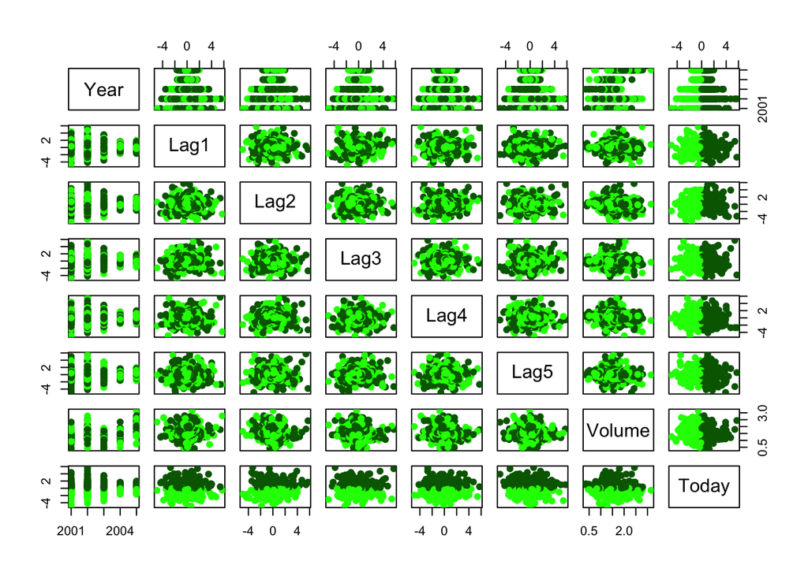

```r
dircolor=rep("green", nrow(Smarket))
dircolor[Smarket$Direction=="Up"]="darkgreen"
pairs(Smarket[,-9], col=dircolor, pch=19)
```

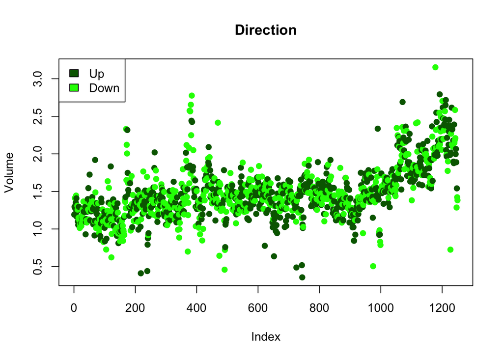

```r
plot(Volume, col=dircolor, pch=19)
legend("topleft", c("Up","Down"),fill=c("darkgreen","green"))
title("Direction")
```

# Data partition

Using Year from 2001 to 2004 for training and 2005 as testing data

```r
data.train <- subset(Smarket, Year != '2005')
dim(data.train)
```

```
## [1] 998   9
```

```r
data.test <- subset(Smarket, Year == '2005')
dim(data.test)
```

```
## [1] 252   9
```

# Logistic Classification

## Training

```r
glm.fits <- glm(Direction~Lag1+Lag2+Lag3+Lag4+Lag5+Volume, data=data.train, family=binomial)
```

## Coefficients

use the coef() to access just the coefficients

use the summary() to access particular values

```r
summary(glm.fits)
```

```
##
## Call:
## glm(formula = Direction ~ Lag1 + Lag2 + Lag3 + Lag4 + Lag5 +
##     Volume, family = binomial, data = data.train)
##
## Deviance Residuals:
##    Min      1Q  Median      3Q     Max
## -1.302  -1.190   1.079   1.160   1.350
##
## Coefficients:
##              Estimate Std. Error z value Pr(>|z|)
## (Intercept)  0.191213   0.333690   0.573    0.567
## Lag1        -0.054178   0.051785  -1.046    0.295
## Lag2        -0.045805   0.051797  -0.884    0.377
## Lag3         0.007200   0.051644   0.139    0.889
## Lag4         0.006441   0.051706   0.125    0.901
## Lag5        -0.004223   0.051138  -0.083    0.934
## Volume      -0.116257   0.239618  -0.485    0.628
##
## (Dispersion parameter for binomial family taken to be 1)
##
##     Null deviance: 1383.3  on 997  degrees of freedom
## Residual deviance: 1381.1  on 991  degrees of freedom
## AIC: 1395.1
##
## Number of Fisher Scoring iterations: 3
```

```r
coef(glm.fits)
```

```
##  (Intercept)         Lag1         Lag2         Lag3         Lag4         Lag5
##  0.191212621 -0.054178292 -0.045805334  0.007200118  0.006440875 -0.004222672
##       Volume
## -0.116256960
```

```r
summary(glm.fits)$coef
```

```
##                 Estimate Std. Error     z value  Pr(>|z|)
## (Intercept)  0.191212621 0.33368991  0.57302488 0.5666278
## Lag1        -0.054178292 0.05178534 -1.04620896 0.2954646
## Lag2        -0.045805334 0.05179687 -0.88432632 0.3765201
## Lag3         0.007200118 0.05164416  0.13941784 0.8891200
## Lag4         0.006440875 0.05170561  0.12456821 0.9008654
## Lag5        -0.004222672 0.05113838 -0.08257344 0.9341907
## Volume      -0.116256960 0.23961830 -0.48517564 0.6275518
```

```r
summary(glm.fits)$coef[,4]
```

```
## (Intercept)        Lag1        Lag2        Lag3        Lag4        Lag5
##   0.5666278   0.2954646   0.3765201   0.8891200   0.9008654   0.9341907
##      Volume
##   0.6275518
```

## Predicting Direction for the training dataset

```r
glm.probs <- predict(glm.fits, data.train, type = "response")
# print first 10 rows
glm.probs[1:10]
```

```
##         1         2         3         4         5         6         7         8
## 0.4985061 0.4893137 0.4849791 0.5098788 0.5145737 0.4982044 0.4835307 0.4984345
##         9        10
## 0.5204107 0.4953121
```

predict gives values between 0 and 1 (float)

contrast() function indicates the Down and Up boolean values created by R

```r
contrasts(Direction)
```

```
##      Up
## Down  0
## Up    1
```

Converting probability (glm.probs) into Direction (Up and Down)

```r
glm.pred <- rep("Down", length(glm.probs))
glm.pred[glm.probs > .5] <- "Up"
glm.pred[1:10]
```

```
##  [1] "Down" "Down" "Down" "Up"   "Up"   "Down" "Down" "Down" "Up"   "Down"
```

## Confusion Matrix - Training Data

```r
library(caret)
cm <- confusionMatrix(data = factor(glm.pred),
                reference = factor(data.train$Direction)
                , positive = "Up")
cm
```

```
## Confusion Matrix and Statistics
##
##           Reference
## Prediction Down  Up
##       Down  175 156
##       Up    316 351
##
##                Accuracy : 0.5271
##                  95% CI : (0.4955, 0.5584)
##     No Information Rate : 0.508
##     P-Value [Acc > NIR] : 0.1207
##
##                   Kappa : 0.049
##
##  Mcnemar's Test P-Value : 2.506e-13
##
##             Sensitivity : 0.6923
##             Specificity : 0.3564
##          Pos Pred Value : 0.5262
##          Neg Pred Value : 0.5287
##              Prevalence : 0.5080
##          Detection Rate : 0.3517
##    Detection Prevalence : 0.6683
##       Balanced Accuracy : 0.5244
##
##        'Positive' Class : Up
##
```

```r
cm[["byClass"]]
```

```
##          Sensitivity          Specificity       Pos Pred Value
##            0.6923077            0.3564155            0.5262369
##       Neg Pred Value            Precision               Recall
##            0.5287009            0.5262369            0.6923077
##                   F1           Prevalence       Detection Rate
##            0.5979557            0.5080160            0.3517034
## Detection Prevalence    Balanced Accuracy
##            0.6683367            0.5243616
```

```r
cfmat(glm.pred, data.train$Direction)
```

```
## Accuracy =  0.5270541
## MCC =  0.05173725
## Recall =  0.6923077
## Precision =  0.5262369
## F1 =  0.5979557
## BS =  0.4729459
```

```
## [[1]]
##       data
## pred   Down  Up
##   Down  175 156
##   Up    316 351
##
## [[2]]
## [1] 0.52705411 0.05173725 0.69230769 0.52623688 0.59795571 0.47294589
```

## Predicting Direction for the testing dataset

```r
glm.probs <- predict(glm.fits, data.test, type = "response")
# print first 10 rows
glm.probs[1:10]
```

```
##       999      1000      1001      1002      1003      1004      1005      1006
## 0.5282195 0.5156688 0.5226521 0.5138543 0.4983345 0.5010912 0.5027703 0.5095680
##      1007      1008
## 0.5040112 0.5106408
```

```r
glm.pred <- rep("Down", length(glm.probs))
glm.pred[glm.probs > .5] <- "Up"
glm.pred[1:10]
```

```
##  [1] "Up"   "Up"   "Up"   "Up"   "Down" "Up"   "Up"   "Up"   "Up"   "Up"
```

## Confusion Matrix - Testing Data - Logistic Classification

```r
cm <- confusionMatrix(data = factor(glm.pred),
                reference = factor(data.test$Direction)
                , positive = "Up")
cm
```

```
## Confusion Matrix and Statistics
##
##           Reference
## Prediction Down Up
##       Down   77 97
##       Up     34 44
##
##                Accuracy : 0.4802
##                  95% CI : (0.417, 0.5437)
##     No Information Rate : 0.5595
##     P-Value [Acc > NIR] : 0.9952
##
##                   Kappa : 0.0054
##
##  Mcnemar's Test P-Value : 6.062e-08
##
##             Sensitivity : 0.3121
##             Specificity : 0.6937
##          Pos Pred Value : 0.5641
##          Neg Pred Value : 0.4425
##              Prevalence : 0.5595
##          Detection Rate : 0.1746
##    Detection Prevalence : 0.3095
##       Balanced Accuracy : 0.5029
##
##        'Positive' Class : Up
##
```

```r
cm[["byClass"]]
```

```
##          Sensitivity          Specificity       Pos Pred Value
##            0.3120567            0.6936937            0.5641026
##       Neg Pred Value            Precision               Recall
##            0.4425287            0.5641026            0.3120567
##                   F1           Prevalence       Detection Rate
##            0.4018265            0.5595238            0.1746032
## Detection Prevalence    Balanced Accuracy
##            0.3095238            0.5028752
```

```r
cfmat(glm.pred, data.test$Direction)
```

```
## Accuracy =  0.4801587
## MCC =  0.006175179
## Recall =  0.3120567
## Precision =  0.5641026
## F1 =  0.4018265
## BS =  0.5198413
```

```
## [[1]]
##       data
## pred   Down Up
##   Down   77 97
##   Up     34 44
##
## [[2]]
## [1] 0.480158730 0.006175179 0.312056738 0.564102564 0.401826484 0.519841270
```

# LDA - Linear Discriminant Analysis

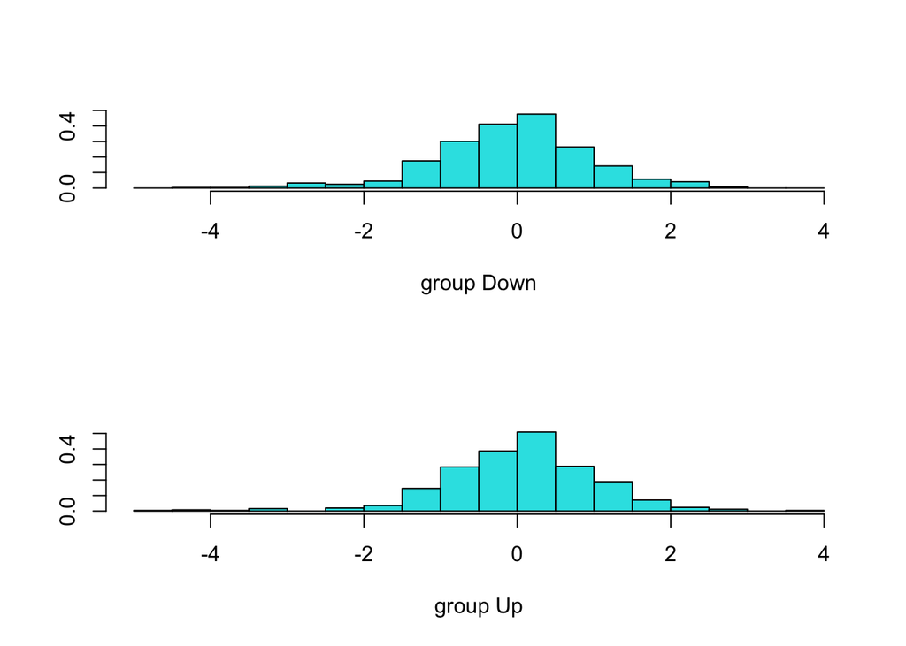

```r
mod.LDA <- lda(Direction ~ Lag1 + Lag2 + Lag3 + Lag4 + Lag5 + Volume, data.train)
plot(mod.LDA)
```

```r
pred.LDA <- predict(mod.LDA, data.test, type = "response")
```

## Confusion Matrix - Testing Data - LDA

```r
cfmat(pred.LDA[["class"]], data.test$Direction)
```

```
## Accuracy =  0.4801587
## MCC =  0.006175179
## Recall =  0.3120567
## Precision =  0.5641026
## F1 =  0.4018265
## BS =  0.5198413
```

```
## [[1]]
##       data
## pred   Down Up
##   Down   77 97
##   Up     34 44
##
## [[2]]
## [1] 0.480158730 0.006175179 0.312056738 0.564102564 0.401826484 0.519841270
```

```r
cm <- confusionMatrix(data = factor(pred.LDA[["class"]]),
                reference = factor(data.test$Direction)
                , positive = "Up")
cm
```

```
## Confusion Matrix and Statistics
##
##           Reference
## Prediction Down Up
##       Down   77 97
##       Up     34 44
##
##                Accuracy : 0.4802
##                  95% CI : (0.417, 0.5437)
##     No Information Rate : 0.5595
##     P-Value [Acc > NIR] : 0.9952
##
##                   Kappa : 0.0054
##
##  Mcnemar's Test P-Value : 6.062e-08
##
##             Sensitivity : 0.3121
##             Specificity : 0.6937
##          Pos Pred Value : 0.5641
##          Neg Pred Value : 0.4425
##              Prevalence : 0.5595
##          Detection Rate : 0.1746
##    Detection Prevalence : 0.3095
##       Balanced Accuracy : 0.5029
##
##        'Positive' Class : Up
##
```

```r
cm[["byClass"]]
```

```
##          Sensitivity          Specificity       Pos Pred Value
##            0.3120567            0.6936937            0.5641026
##       Neg Pred Value            Precision               Recall
##            0.4425287            0.5641026            0.3120567
##                   F1           Prevalence       Detection Rate
##            0.4018265            0.5595238            0.1746032
## Detection Prevalence    Balanced Accuracy
##            0.3095238            0.5028752
```

# QDA - Quadratic Discriminant Analysis

```r
mod.QDA <- qda(Direction ~ Lag1 + Lag2 + Lag3 + Lag4 + Lag5 + Volume, data.train)
pred.QDA <- predict(mod.QDA, data.test, type = "response")
```

## Confusion Matrix - Testing Data - QDA

```r
cfmat(pred.QDA$class, data.test$Direction)
```

```
## Accuracy =  0.4444444
## MCC =  -0.05685466
## Recall =  0.212766
## Precision =  0.5084746
## F1 =  0.3
## BS =  0.5555556
```

```
## [[1]]
##       data
## pred   Down  Up
##   Down   82 111
##   Up     29  30
##
## [[2]]
## [1]  0.44444444 -0.05685466  0.21276596  0.50847458  0.30000000  0.55555556
```

```r
cm <- confusionMatrix(data = factor(pred.QDA$class),
                reference = factor(data.test$Direction)
                , positive = "Up")
cm
```

```
## Confusion Matrix and Statistics
##
##           Reference
## Prediction Down  Up
##       Down   82 111
##       Up     29  30
##
##                Accuracy : 0.4444
##                  95% CI : (0.3821, 0.5081)
##     No Information Rate : 0.5595
##     P-Value [Acc > NIR] : 0.9999
##
##                   Kappa : -0.045
##
##  Mcnemar's Test P-Value : 7.608e-12
##
##             Sensitivity : 0.2128
##             Specificity : 0.7387
##          Pos Pred Value : 0.5085
##          Neg Pred Value : 0.4249
##              Prevalence : 0.5595
##          Detection Rate : 0.1190
##    Detection Prevalence : 0.2341
##       Balanced Accuracy : 0.4758
##
##        'Positive' Class : Up
##
```

```r
cm[["byClass"]]
```

```
##          Sensitivity          Specificity       Pos Pred Value
##            0.2127660            0.7387387            0.5084746
##       Neg Pred Value            Precision               Recall
##            0.4248705            0.5084746            0.2127660
##                   F1           Prevalence       Detection Rate
##            0.3000000            0.5595238            0.1190476
## Detection Prevalence    Balanced Accuracy
##            0.2341270            0.4757523
```

# KNN - k-nearest neighbors algorithm

```r
mod.KNN <- knn(train = data.train[, 2:7], test = data.test[, 2:7], cl = data.train$Direction, k = 20)
```

```r
cfmat(mod.KNN, data.test$Direction)
```

```
## Accuracy =  0.4603175
## MCC =  -0.07155198
## Recall =  0.4326241
## Precision =  0.5213675
## F1 =  0.4728682
## BS =  0.5396825
```

```
## [[1]]
##       data
## pred   Down Up
##   Down   55 80
##   Up     56 61
##
## [[2]]
## [1]  0.46031746 -0.07155198  0.43262411  0.52136752  0.47286822  0.53968254
```

```r
cm <- confusionMatrix(data = factor(mod.KNN),
                reference = factor(data.test$Direction)
                , positive = "Up")
cm
```

```
## Confusion Matrix and Statistics
##
##           Reference
## Prediction Down Up
##       Down   55 80
##       Up     56 61
##
##                Accuracy : 0.4603
##                  95% CI : (0.3976, 0.524)
##     No Information Rate : 0.5595
##     P-Value [Acc > NIR] : 0.99936
##
##                   Kappa : -0.0703
##
##  Mcnemar's Test P-Value : 0.04858
##
##             Sensitivity : 0.4326
##             Specificity : 0.4955
##          Pos Pred Value : 0.5214
##          Neg Pred Value : 0.4074
##              Prevalence : 0.5595
##          Detection Rate : 0.2421
##    Detection Prevalence : 0.4643
##       Balanced Accuracy : 0.4641
##
##        'Positive' Class : Up
##
```

```r
cm[["byClass"]]
```

```
##          Sensitivity          Specificity       Pos Pred Value
##            0.4326241            0.4954955            0.5213675
##       Neg Pred Value            Precision               Recall
##            0.4074074            0.5213675            0.4326241
##                   F1           Prevalence       Detection Rate
##            0.4728682            0.5595238            0.2420635
## Detection Prevalence    Balanced Accuracy
##            0.4642857            0.4640598
```

# Decision Tree

```r
library(rpart)
library(rpart.plot)
```

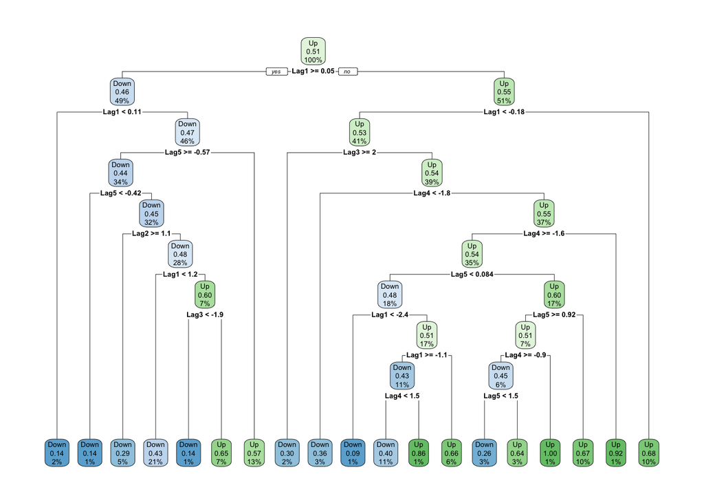

```r
treefit <- rpart(Direction ~ Lag1 + Lag2 + Lag3 + Lag4 + Lag5, method = "class", data = data.train)
rpart.plot(treefit)
```

```r
treefit$cptable
```

```
##           CP nsplit rel error    xerror       xstd
## 1 0.08146640      0 1.0000000 1.0651731 0.03213297
## 2 0.01731161      1 0.9185336 0.9653768 0.03212980
## 3 0.01086219      3 0.8839104 0.9959267 0.03216374
## 4 0.01018330     10 0.8004073 1.0468432 0.03215566
## 5 0.01000000     18 0.7189409 1.0407332 0.03216090
```

From: https://discuss.analyticsvidhya.com/t/how-does-complexity-parameter-cp-work-in-decision-tree/6589

“The complexity parameter (cp) is used to control the size of the decision tree and to select the optimal tree size. If the cost of adding another variable to the decision tree from the current node is above the value of cp, then tree building does not continue. We could also say that tree construction does not continue unless it would decrease the overall lack of fit by a factor of cp.”

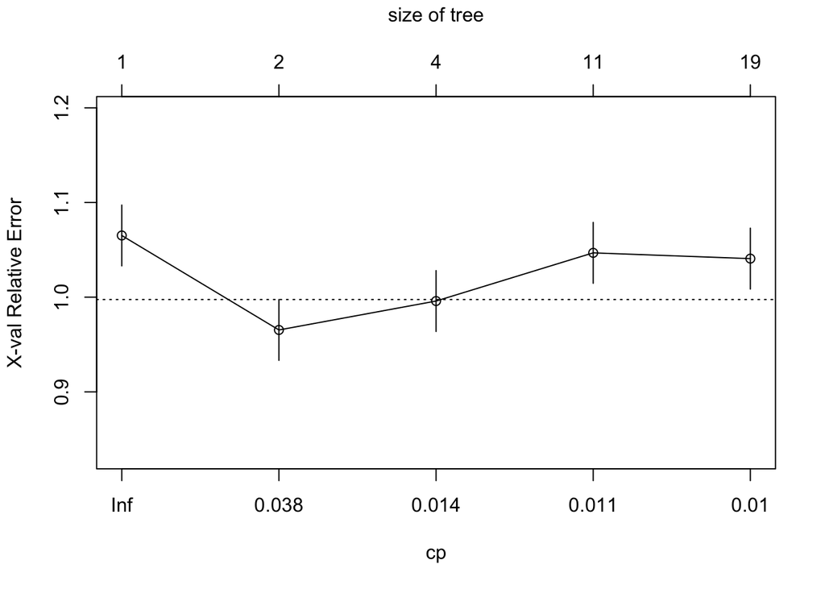

```r
plotcp(treefit)
```

## Prune

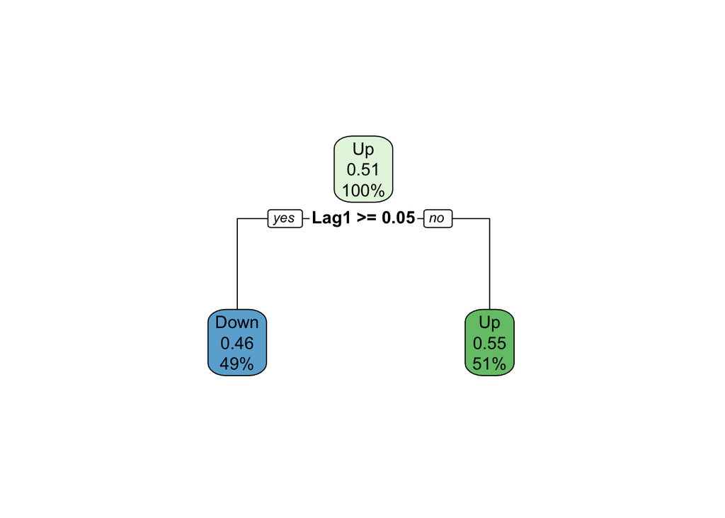

```r
best_cp <- treefit$cptable[which.min(treefit$cptable[, "xerror"]), "CP"]
prunefit <- rpart::prune(treefit, cp = best_cp)
rpart.plot(prunefit)
```